# Image features exercise

*Complete and hand in this completed worksheet (including its outputs and any supporting code outside of the worksheet) with your assignment submission. For more details see the [assignments page](https://course.cse.ust.hk/comp4901j/Password_Only/programs/assignment1/index.html) on the course website.*

We have seen that we can achieve reasonable performance on an image classification task by training a linear classifier on the pixels of the input image. In this exercise we will show that we can improve our classification performance by training linear classifiers not on raw pixels but on features that are computed from the raw pixels.

All of your work for this exercise will be done in this notebook.

```python
import random
import numpy as np
from cs231n.data_utils import load_CIFAR10
import matplotlib.pyplot as plt

from __future__ import print_function

%matplotlib inline
plt.rcParams['figure.figsize'] = (10.0, 8.0) # set default size of plots
plt.rcParams['image.interpolation'] = 'nearest'
plt.rcParams['image.cmap'] = 'gray'

# for auto-reloading extenrnal modules
# see http://stackoverflow.com/questions/1907993/autoreload-of-modules-in-ipython
%load_ext autoreload
%autoreload 2
```

## Load data

Similar to previous exercises, we will load CIFAR-10 data from disk.

```python
from cs231n.features import color_histogram_hsv, hog_feature

def get_CIFAR10_data(num_training=49000, num_validation=1000, num_test=1000):
    # Load the raw CIFAR-10 data
    cifar10_dir = 'cs231n/datasets/cifar-10-batches-py'
    X_train, y_train, X_test, y_test = load_CIFAR10(cifar10_dir)

    # Subsample the data
    mask = list(range(num_training, num_training + num_validation))
    X_val = X_train[mask]
    y_val = y_train[mask]
    mask = list(range(num_training))
    X_train = X_train[mask]
    y_train = y_train[mask]
    mask = list(range(num_test))
    X_test = X_test[mask]
    y_test = y_test[mask]

    return X_train, y_train, X_val, y_val, X_test, y_test

X_train, y_train, X_val, y_val, X_test, y_test = get_CIFAR10_data()
```

## Extract Features

For each image we will compute a Histogram of Oriented Gradients (HOG) as well as a color histogram using the hue channel in HSV color space. We form our final feature vector for each image by concatenating the HOG and color histogram feature vectors.

Roughly speaking, HOG should capture the texture of the image while ignoring color information, and the color histogram represents the color of the input image while ignoring texture. As a result, we expect that using both together ought to work better than using either alone. Verifying this assumption would be a good thing to try for the bonus section.

```python
from cs231n.features import *

num_color_bins = 10 # Number of bins in the color histogram
feature_fns = [hog_feature, lambda img: color_histogram_hsv(img, nbin=num_color_bins)]
X_train_feats = extract_features(X_train, feature_fns, verbose=True)
X_val_feats = extract_features(X_val, feature_fns)
X_test_feats = extract_features(X_test, feature_fns)

# Preprocessing: Subtract the mean feature
mean_feat = np.mean(X_train_feats, axis=0, keepdims=True)
X_train_feats -= mean_feat
X_val_feats -= mean_feat
X_test_feats -= mean_feat

# Preprocessing: Divide by standard deviation. This ensures that each feature
# has roughly the same scale.
std_feat = np.std(X_train_feats, axis=0, keepdims=True)
X_train_feats /= std_feat
X_val_feats /= std_feat
X_test_feats /= std_feat

# Preprocessing: Add a bias dimension
X_train_feats = np.hstack([X_train_feats, np.ones((X_train_feats.shape[0], 1))])
X_val_feats = np.hstack([X_val_feats, np.ones((X_val_feats.shape[0], 1))])
X_test_feats = np.hstack([X_test_feats, np.ones((X_test_feats.shape[0], 1))])
```

[output not shown]

## Train SVM on features

Using the multiclass SVM code developed earlier in the assignment, train SVMs on top of the features extracted above; this should achieve better results than training SVMs directly on top of raw pixels.

```python
# Use the validation set to tune the learning rate and regularization strength

from cs231n.classifiers.linear_classifier import LinearSVM

learning_rates = [5e-7, 1.5e-6]
regularization_strengths = [1e4, 1e5]

results = {}
best_val = -1
best_svm = None

pass
################################################################################
# DONE:                                                                        #
# Use the validation set to set the learning rate and regularization strength. #
# This should be identical to the validation that you did for the SVM; save    #
# the best trained classifer in best_svm. You might also want to play          #
# with different numbers of bins in the color histogram. If you are careful    #
# you should be able to get accuracy of near 0.44 on the validation set.       #
################################################################################
for rate in np.arange(*learning_rates, 2e-7):
    for reg in np.arange(*regularization_strengths, 2e4):
        temp_svm = LinearSVM()
        temp_svm.train(X_train_feats, y_train, learning_rate=rate, reg=reg,
                      num_iters=3000, verbose=False)
        train_pred = temp_svm.predict(X_train_feats)
        train_prec = np.mean(train_pred == y_train)
        val_pred = temp_svm.predict(X_val_feats)
        val_prec = np.mean(val_pred == y_val)
        results[rate, reg] = [train_prec, val_prec]
        if val_prec > best_val:
            best_val = val_prec
            best_svm = temp_svm
################################################################################
#                              END OF YOUR CODE                                #
################################################################################

# Print out results.
for lr, reg in sorted(results):
    train_accuracy, val_accuracy = results[(lr, reg)]
    print('lr %e reg %e train accuracy: %f val accuracy: %f' % (
                lr, reg, train_accuracy, val_accuracy))

print('best validation accuracy achieved during cross-validation: %f' % best_val)
```

```
lr 5.000000e-07 reg 1.000000e+04 train accuracy: 0.416347 val accuracy: 0.420000
lr 5.000000e-07 reg 3.000000e+04 train accuracy: 0.407143 val accuracy: 0.403000
lr 5.000000e-07 reg 5.000000e+04 train accuracy: 0.407082 val accuracy: 0.395000
lr 5.000000e-07 reg 7.000000e+04 train accuracy: 0.407204 val accuracy: 0.413000
lr 5.000000e-07 reg 9.000000e+04 train accuracy: 0.398490 val accuracy: 0.399000
lr 7.000000e-07 reg 1.000000e+04 train accuracy: 0.411020 val accuracy: 0.415000
lr 7.000000e-07 reg 3.000000e+04 train accuracy: 0.412837 val accuracy: 0.427000
lr 7.000000e-07 reg 5.000000e+04 train accuracy: 0.409184 val accuracy: 0.412000
lr 7.000000e-07 reg 7.000000e+04 train accuracy: 0.412735 val accuracy: 0.414000
lr 7.000000e-07 reg 9.000000e+04 train accuracy: 0.397224 val accuracy: 0.405000
lr 9.000000e-07 reg 1.000000e+04 train accuracy: 0.412918 val accuracy: 0.412000
lr 9.000000e-07 reg 3.000000e+04 train accuracy: 0.410082 val accuracy: 0.396000
lr 9.000000e-07 reg 5.000000e+04 train accuracy: 0.406939 val accuracy: 0.401000
lr 9.000000e-07 reg 7.000000e+04 train accuracy: 0.408429 val accuracy: 0.426000
lr 9.000000e-07 reg 9.000000e+04 train accuracy: 0.401735 val accuracy: 0.402000
lr 1.100000e-06 reg 1.000000e+04 train accuracy: 0.411592 val accuracy: 0.412000
lr 1.100000e-06 reg 3.000000e+04 train accuracy: 0.416449 val accuracy: 0.414000
lr 1.100000e-06 reg 5.000000e+04 train accuracy: 0.407327 val accuracy: 0.396000
lr 1.100000e-06 reg 7.000000e+04 train accuracy: 0.404939 val accuracy: 0.402000
lr 1.100000e-06 reg 9.000000e+04 train accuracy: 0.399102 val accuracy: 0.414000
lr 1.300000e-06 reg 1.000000e+04 train accuracy: 0.412918 val accuracy: 0.410000
lr 1.300000e-06 reg 3.000000e+04 train accuracy: 0.420102 val accuracy: 0.422000
lr 1.300000e-06 reg 5.000000e+04 train accuracy: 0.402020 val accuracy: 0.392000
lr 1.300000e-06 reg 7.000000e+04 train accuracy: 0.406673 val accuracy: 0.420000
lr 1.300000e-06 reg 9.000000e+04 train accuracy: 0.387061 val accuracy: 0.396000
lr 1.500000e-06 reg 1.000000e+04 train accuracy: 0.412571 val accuracy: 0.409000
lr 1.500000e-06 reg 3.000000e+04 train accuracy: 0.409755 val accuracy: 0.401000
lr 1.500000e-06 reg 5.000000e+04 train accuracy: 0.392143 val accuracy: 0.373000
lr 1.500000e-06 reg 7.000000e+04 train accuracy: 0.400082 val accuracy: 0.399000
lr 1.500000e-06 reg 9.000000e+04 train accuracy: 0.388245 val accuracy: 0.388000
best validation accuracy achieved during cross-validation: 0.427000
```

```python
# Evaluate your trained SVM on the test set
y_test_pred = best_svm.predict(X_test_feats)
test_accuracy = np.mean(y_test == y_test_pred)
print(test_accuracy)
```

```
0.418
```

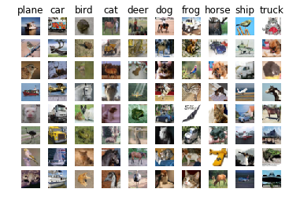

```python
# An important way to gain intuition about how an algorithm works is to
# visualize the mistakes that it makes. In this visualization, we show examples
# of images that are misclassified by our current system. The first column
# shows images that our system labeled as "plane" but whose true label is
# something other than "plane".

examples_per_class = 8
classes = ['plane', 'car', 'bird', 'cat', 'deer', 'dog', 'frog', 'horse', 'ship', 'truck']
for cls, cls_name in enumerate(classes):
    idxs = np.where((y_test != cls) & (y_test_pred == cls))[0]
    idxs = np.random.choice(idxs, examples_per_class, replace=False)
    for i, idx in enumerate(idxs):
        plt.subplot(examples_per_class, len(classes), i * len(classes) + cls + 1)
        plt.imshow(X_test[idx].astype('uint8'))
        plt.axis('off')
        if i == 0:
            plt.title(cls_name)
plt.show()
```

### Inline question 1:

Describe the misclassification results that you see. Do they make sense?

They make senses to some extent. They are misclassified because their looks resemble to the classes predicted.